# Bootstrap

## An review of Sampling Distributions (how and why):

1. Start with a *known* population. That is, I know something about its distribution.
2. Generate a *sampling distribution* for some statistic (mean, max, proportion, etc.):
   1. Pull a random sample
   2. Compute a statistic (mean, max, etc.) of that sample.
   3. Record that value
   4. Repeat
   5. The collection of these sample statistics *is* the sample distribution.
3. Use the sampling distribution to compute probabilities:
   - Eg. What is the probability that the mean of a sample is ____?

## The problem: We *don’t know* the population.

## The *bootstrap* solution:

- Use a sample *in place of* the population,
- generate a *bootstrap* distribution from this sample (we’ll get there)
- Ask: Can I use the bootstrap distribution in the same way I’d use a (theoretical) sampling distribution?
- If not, what can I do with it?

## How to contruct a *bootstrap* distribution and comparison to sampling distribution

In order to do the comparison part we’ll start with a *known* distribution.

Keep in mind this is the part we can’t do in practice. We do it here to see if a bootstrap distribution is of any value.

### Known distribution:

normal with mean $\mu=36$ and standard deviation $\sigma = 8$.

Here is the distribution:

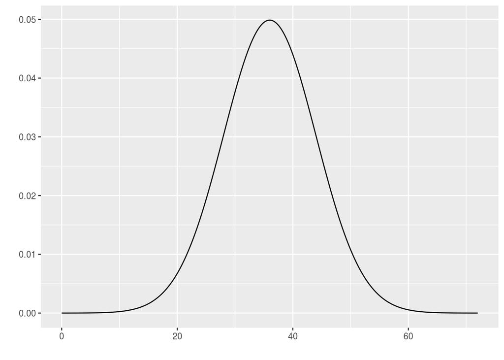

```r
library(ggfortify)
mu <- 36
sigma <- 8
ggdistribution(dnorm, seq(0, 72, 0.1), mean=mu, sd=sigma)
```

We know from the CLT that the sampling distribution of the mean for samples of size $n=200$ is *normal*, has mean $\mu=36$, and standard error $\text{S.E.}=\frac{\sigma}{\sqrt{n}}$. Here is its plot:

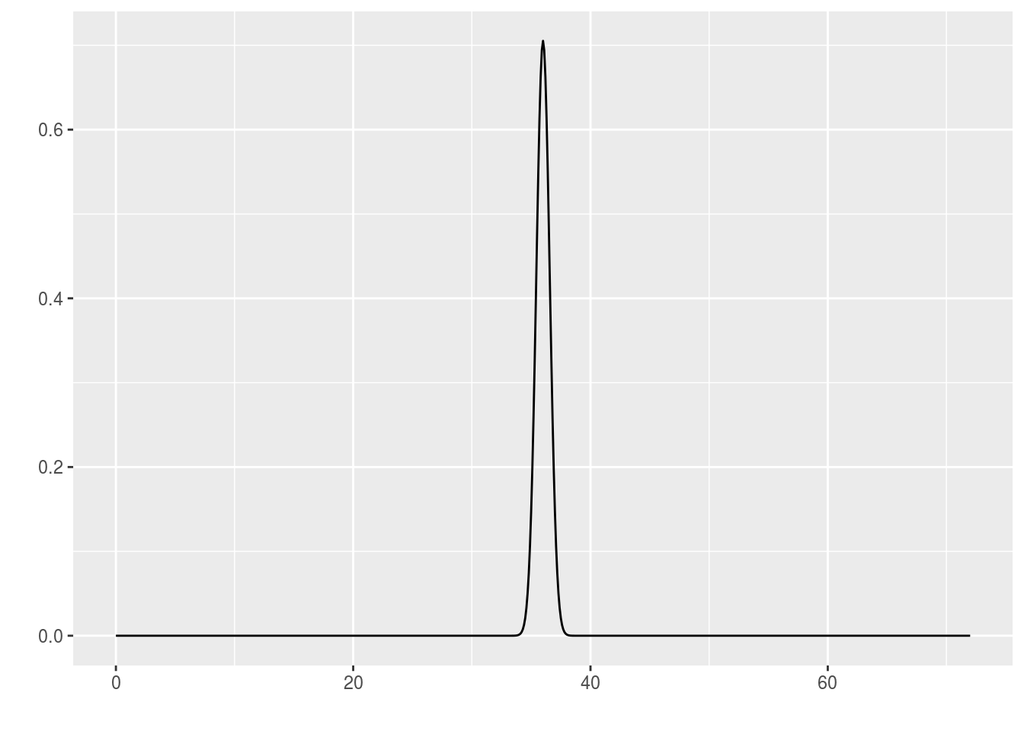

```r
n <- 200
ggdistribution(dnorm, seq(0, 72, 0.1), mean=mu, sd=sigma/sqrt(n))
```

This is the *theoretical* sampling distribution. Theoretical in the sense that we started with a *known* population.

### Bootstrap method

- We’ll start by drawing a random sample of size $n=200$ (same size as in the sampling distribution) from the population:

```r
BaseSample <- rnorm(n, mean=mu, sd=sigma)
```

Look at it so you know what it is:

```r
head(BaseSample)
```

```
## [1] 41.17668 43.76298 30.30880 31.66913 40.78356 36.64314
```

It is a vector of numbers chosen randomly from the population distribution.

- Now, in the bootstrap procedure we are going to treat `BaseSample` as the population. From here until the end pretend we *don’t know* the population.
- We are going to resample and compute the mean of each resample, just as we would to find a sampling distribution, but:
  - We are going to pick resamples of size 200! The same size as `BaseSample`.
  - This only makes sense if we allow replacement: `replace=T`. Otherwise we simply get the same sample over and over.
- We repeat, say 1000 times.
- the result is the *bootstrap distribution*:

```r
N <- 1000
BootDist <- numeric(N)
for (i in 1:N)
{samp <- sample(BaseSample, n, replace=T)
BootDist[i] <- mean(samp)}
```

Look at it to see what you’ve created:

```r
head(BootDist)
```

```
## [1] 37.04613 36.24812 37.25553 36.53525 37.40648 36.70610
```

This is a vector whose entries are means of each of the resamples. There are 1000 entries in this vector.

Look at the graphical representation of this distribution:

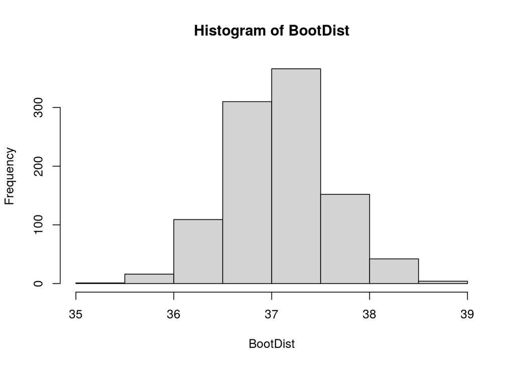

```r
hist(BootDist)
```

We’ll plot the *sampling distribution* on a similar scale:

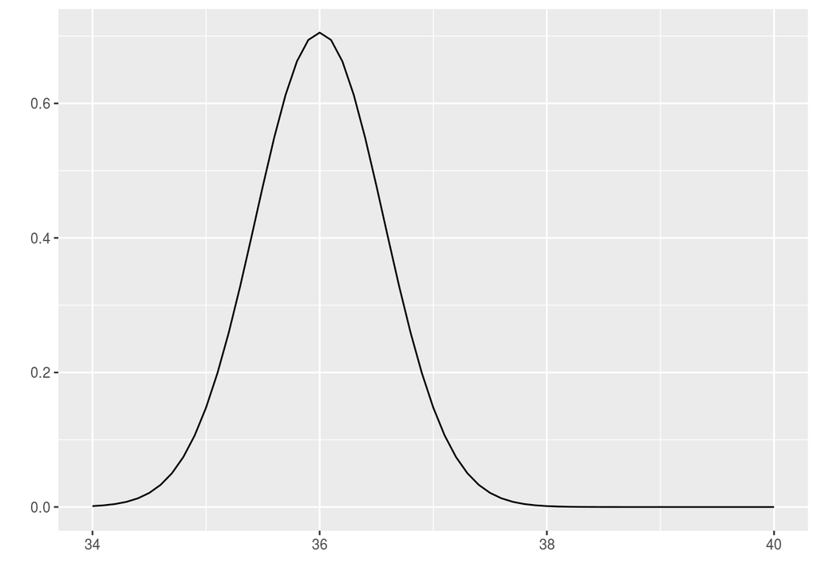

```r
ggdistribution(dnorm, seq(34, 40, 0.1), mean=mu, sd=sigma/sqrt(n))
```

```r
sigma/sqrt(n)
```

```
## [1] 0.5656854
```

- The mean of the bootstrap distribution is:

```r
mean(BootDist)
```

```
## [1] 37.09041
```

(depending on my knit this value may be close to 36, but not always)

- The standard deviation of the bootstrap distribution is:

```r
sd(BootDist)
```

```
## [1] 0.5193537
```

One more comparison:

```r
mean(BaseSample)
```

```
## [1] 37.08186
```

So, the mean of the bootstrap distribuion is similar to the mean of `BaseSample`. This is not unexpected, it also isn’t particularly useful. We want to say something about the mean of *real* popultion, not the mean of the sample.

We’ll keep this in mind:

- Bootstraping does a good job giving the *shape* of the sampling distribution.
- Bootstraping does a good job giving the *spread* of the sampling distribution.
- Bootstraping does *not* do a good job giving the *center* of the sampling distribuiton.

We’ll see how to use this next….

The HW asks for a table. Here is quick and dirty way to make a table:

```r
Distribution <- c("Population", "Sample Distribution", "Sample", "Bootstrap Distribution")
means <- c(mu, mu, mean(BaseSample), mean(BootDist))
sdevs <- c(sigma, sigma/sqrt(n), sd(BaseSample),sd(BootDist))
results <- cbind(Distribution, means, sdevs)
knitr::kable(results, digits=2)
```

| Distribution | means | sdevs |
| --- | --- | --- |
| Population | 36 | 8 |
| Sample Distribution | 36 | 0.565685424949238 |
| Sample | 37.0818614886733 | 7.48941741953528 |
| Bootstrap Distribution | 37.0904074034609 | 0.519353703110282 |